# Représentation des stats calculées par MetHis

## Librairies utilisées

```r
library(stringr)
library(ggplot2)
require(MASS)
```

## Vérification des priors utilisés

Fonction

```r
#Data frame prior
data.frame.prior = function(seq_ne, max_simu){
  #Créer matrice vide qui contiendra les stats
  mat_prior = matrix(data = NA, nrow = length(seq_ne)*max_simu, ncol = 4)
  #Attribution nom colonnes selon appelation stat par MetHis
  colnames(mat_prior) = c("Ne", "simu", "s1", "s2")
  mat_prior = as.data.frame(mat_prior)
  #Compteur pour indiquer les lignes à remplir
  cpt = 0

  for (ne in seq_ne) {
    dir_ne = str_c("Ne", toString(ne), "/") #Répertoire de taille effective
    row_min = cpt*max_simu+1
    row_max = (cpt+1)*max_simu
    mat_prior[row_min:row_max,1] = toString(ne)
    cpt = cpt+1

    for (nb_simu in 1:max_simu) {
      mat_prior[row_min+nb_simu-1,2] = nb_simu
      dir_simu = str_c("simu_", toString(nb_simu), "/")
      file_path = str_c(dir_ne, dir_simu, "simu_", nb_simu, ".txt")
      df_tmp = read.table(file_path, header = TRUE)
      mat_prior[row_min+nb_simu-1,3:4] = df_tmp[1,5:6]
    }
  }


  #Passage des Ne en facteur
  mat_prior$Ne = factor(as.factor(mat_prior$Ne), levels = as.character(seq_ne))
  #Passage simuulations en entier
  mat_prior$simu = as.integer(mat_prior$simu)

  return(mat_prior)
}
```

Application

```r
seq_64_8192 = 2**seq(6,13,1)
seq_60_100 = 10*seq(5,10,1)
seq_tot = sort(c(seq_60_100, seq_64_8192))
mat_prior_tot = data.frame.prior(seq_tot, 1)
summary(mat_prior_tot$s1)
```

```
##     Min.  1st Qu.   Median     Mean  3rd Qu.     Max.
## 0.002154 0.192779 0.371849 0.360288 0.490594 0.748215
```

## Résumé des lectures de stat

```bash
#Script bash pour réduire le nombre d'ouvertures de fichier en R.
#Attention !!! Script à utiliser s'il y a de nouvelles simulations
#et doit être modifié si de nouveaux sous-répertoires sont ajoutés
#2 lignes à ajouter dans ce cas : "cd $path_to_directory" et "set_resum_stat"
#Ne pas utiliser si répertoire cloné du github

#set_resum_stat()
#{
#  list_Ne=$(ls -d Ne*)

#  for Ne in $list_Ne; do
#      cd $Ne
#      list_simu=$(ls -d simu_*)
#      for simu in $list_simu; do
#        cd $simu
#        #rm final_sumstats.txt
#        for (( num = 0; num < 101; num++ )); do
#          #echo "final_sumstats$num.txt"
#          cat "final_sumstats$num.txt" >> tmp.txt
#        done
#        nl tmp.txt | sort --key 2 --unique | sort --key 1 --numeric-sort > final_sumstats.txt
#        rm tmp.txt
#        cd ../
#      done
#      cd ../
#  done
#}

#set_resum_stat

#cd ../new_methis_pop_increase
#set_resum_stat
```

On choisit donc ici : - de concaténer pour chaque génération de chaque effectif efficace l’ensemble des statistiques calculées sur les x simulations (bash) - de calculer la moyenne pour chaque statistique sur l’ensemble des simulations, ce qui correspondra aux statistiques pour la génération donnée - on peut ensuite observer une statistique choisie en fonction des générations, pour observer l’évolution de cet indicateur au cours du temps.

La fonction décrite ci-dessus respecte donc ce schéma, en enregistrant les données dans une matrice à 62 colonnes, avec l’effectif efficace sur la première colonne, la génération sur la deuxième, et les statistiques sur les colonnes 3 à 62.

## Fonctions utilisées

```r
#Data frame construction
data.frame.stat = function(seq_ne, max_gen, max_simu){

  #Créer matrice vide qui contiendra les stats
  mat_stat = matrix(data = NA, nrow = length(seq_ne)*max_gen*max_simu, ncol = 63)
  mat_stat = as.data.frame(mat_stat)
  #Compteur pour indiquer les lignes à remplir
  cpt = 0

  for (ne in seq_ne) {
    dir_ne = str_c("Ne", toString(ne), "/") #Répertoire de taille effective
    row_min = cpt*max_gen*max_simu+1 #Ligne min. où on écrit les stats pour le Ne donné
    row_max = (cpt+1)*max_gen*max_simu         #Ligne max. où on écrit les stats
    mat_stat[row_min:row_max,1] = toString(ne) #Ecriture du Ne correspondant pour les stats qui seront écrites
    cpt = cpt+1                             #Incrémentation du compteur

    for (nb_simu in 1:max_simu) {
      dir_simu = str_c("simu_", toString(nb_simu), "/")
      row_min_simu = (nb_simu-1)*max_gen + row_min
      row_max_simu = nb_simu*max_gen + row_min -1
      mat_stat[row_min_simu:row_max_simu,2] = nb_simu
      file_path = str_c(dir_ne, dir_simu, "final_sumstats.txt")
      file_stat = read.table(file_path, header = TRUE) #Lecture fichier stat résumées
      #Suppression 1ère colonne, contenant uniquement chiffres pour tri en bash.
      file_stat = file_stat[,-1]
      mat_stat[row_min_simu:row_max_simu,3] = 0:100
      mat_stat[row_min_simu:row_max_simu,4:63] = file_stat
    }
  }


  #Attribution nom colonnes selon appelation stat par MetHis
  colnames(mat_stat) = c("Ne", "simu", "gen", names(file_stat))
  #Passage des Ne en facteur
  mat_stat$Ne = factor(as.factor(mat_stat$Ne), levels = as.character(seq_ne))
  #Passage simulations en entier
  mat_stat$simu = as.integer(mat_stat$gen)
  #Passage générations en entier
  mat_stat$gen = as.integer(mat_stat$gen)
  #Passage stats en double
  for (numcol in 4:ncol(mat_stat)) {
    mat_stat[,numcol] = as.double(mat_stat[,numcol])
  }

  return(mat_stat)
}
```

```r
#Passage en moyenne
data.frame.mean = function(df_stat, max_gen, seq_ne){

  lrow = length(names(summary(df_stat$Ne)))
  df_mean = matrix(data = NA, nrow = lrow*max_gen, ncol = 62 )
  df_mean = as.data.frame(df_mean)
  cpt = 0

  for (ne in names(summary(df_stat$Ne))) {
    df_tmp = df_stat[which(df_stat$Ne == ne),]

    row_min = cpt*max_gen+1
    row_max = (cpt+1)*max_gen
    df_mean[row_min:row_max, 1] = toString(ne)
    cpt = cpt+1

    for (gen in 0:(max_gen-1) ) {
      df_mean[row_min+gen, 2] = gen
      vec_tmp = apply(df_tmp[which(df_tmp$gen == gen), 4:63], 2, mean)
      df_mean[row_min+gen, 3:62] = vec_tmp
    }
  }

  colnames(df_mean) = colnames(df_stat)[-2]
  df_mean$Ne = factor(as.factor(df_mean$Ne), levels = seq_ne )
  return(df_mean)
}
```

```r
#Plot function
#Affichage d'une stat au cours des générations
plot_stat_gen = function(df, gen, stat, color_col, titre, ligne = FALSE, legd = TRUE){
  p = ggplot(df, aes(x = gen, y = stat, color = color_col)) + ggtitle(titre)

  if (ligne) {
    p = p + geom_point(size = 0.1, show.legend = legd)+ geom_line(show.legend = legd)
  }else{
    #smooth de la courbe pour obtenir régression et tempérer variabilité due au TCL
    p = p + geom_point(size = 0.1, show.legend = legd)+ geom_smooth(show.legend = legd)
  }

  print(p)
  return(p)
}
```

```r
extract_sub_mat = function(all_mat, list_ne){
  all_rows = c()
  for (ne in as.character(list_ne)) {
    all_rows = append(all_rows, which(all_mat[,1] == ne))
  }
  return(all_mat[all_rows,])
}
```

## Population constante de tailles initiales différentes

Calcul des matrices de stats

```r
seq_64_8192 = 2**seq(10,14,1)
seq_60_100 = 10*seq(5,100,1)
seq_tot = sort(c(seq_60_100, seq_64_8192))

mat_tot = data.frame.stat(seq_tot, 101, 1)
mat_60_100 = extract_sub_mat(mat_tot, seq_60_100)
mat_64_8192 = extract_sub_mat(mat_tot, seq_64_8192)

#mat_tot_mean = data.frame.mean(mat_tot, 101, seq_tot)
```

Graphiques obtenus

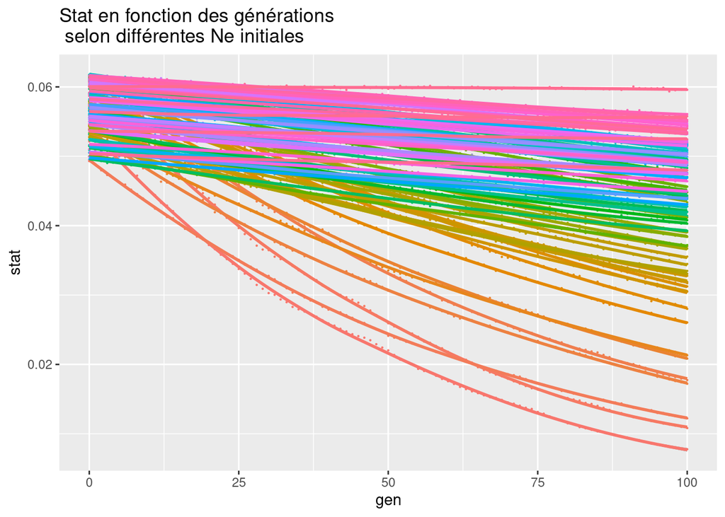

```r
p = plot_stat_gen(mat_tot, mat_tot$gen,
              mat_tot$mean.het.adm, mat_tot$Ne,
              "Stat en fonction des générations\n selon différentes Ne initiales",
              legd = FALSE)
```

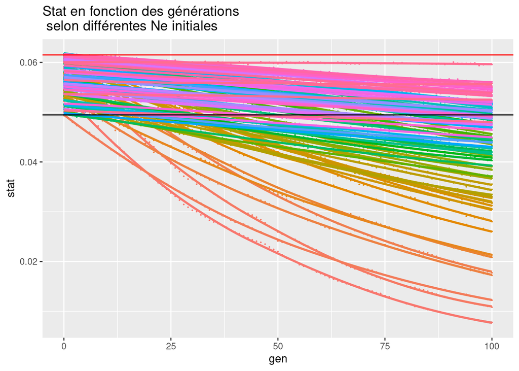

```r
p = p + geom_hline(yintercept = mat_tot$mean.het.s1[1],
                           color = "red")
p = p + geom_hline(yintercept = mat_tot$mean.het.s2[1],
                           color = "black")
print(p)
```

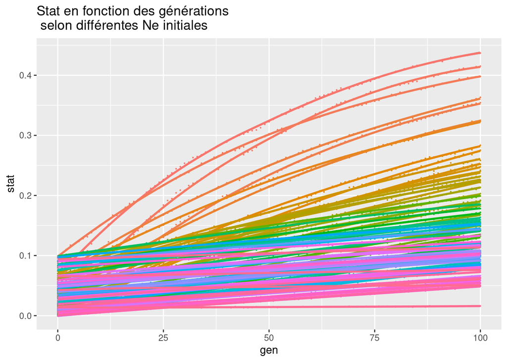

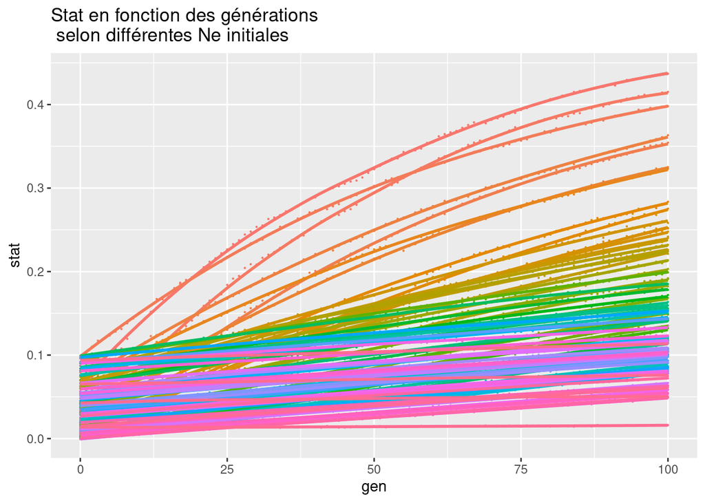

```r
plot_stat_gen(mat_tot, mat_tot$gen,
              mat_tot$Fst.s1.adm, mat_tot$Ne,
              "Stat en fonction des générations\n selon différentes Ne initiales",
              legd = FALSE)
```

```r
#plot_stat_gen(mat_64_8192, mat_64_8192$gen,
#              mat_64_8192$f3, mat_64_8192$Ne,
#              "Stat en fonction des générations\n selon différentes Ne initiales")
#plot_stat_gen(mat_64_8192, mat_64_8192$gen,
#              mat_64_8192$mean.adm.angles, mat_64_8192$Ne,
#              "Stat en fonction des générations\n selon différentes Ne initiales")
#plot_stat_gen(mat_64_8192, mat_64_8192$gen,
#              mat_64_8192$mean.adm.props, mat_64_8192$Ne,
#              "Stat en fonction des générations\n selon différentes Ne initiales", #TRUE)
```